# Informe_Moviles

KEVIN FERNANDO ECHEVERRI RODRIGUEZ 1005028744

## **INFORME MEDICIONES MOVILES Y APLICACION DE MODELOS**

**IMPORTACION DE LIBRERIAS**

```python
import pandas as pd
import numpy as np
import matplotlib.pyplot as plt
import math
```

## Tabla de Móviles

|  | MOVILES_JORGE | VILLA2024 |
| --- | --- | --- |
| Frecuencia | 2400 Mhz | 2400 Mhz |
| Altura | 2.47 m | 2.47 m |
| Potencia de transmisión | 27 dBm | 17 dBm |
| Potencia de recepción | 3 dBm | 3 dBm |

**ESTADÍSTICAS**

La función estadisticas realiza un análisis estadístico de un conjunto de datos de medidas de RSSI (Received Signal Strength Indication) para diferentes puntos.

*dataMedidas:* Es un diccionario donde las claves representan los puntos de medición y los valores son DataFrames que contienen las mediciones de RSSI para cada punto.  
->Se copian los datos de RSSI del DataFrame dataFrame a la variable data.  
->Se realizan ajustes para asegurar que haya suficientes datos para realizar cálculos estadísticos(Si no hay datos, se añade un valor de -100 y si hay solo un dato, se duplica ese dato.)

```python
def estadisticas(dataMedidas):
    calculos = []
    k = 0

    for punto, dataFrame in dataMedidas.items():

        data = dataFrame["RSSI"].copy()

    #ASEGURAR TOTALIDAD DE DATOS
        if (len(data)<=0):
            data.at[0] = -100

        if(len(data)==1):
            data.at[1] = data.at[0]


    #APLICACION DE ESTADISTICA

        distancia = k * 5 if k != 0 else 1
        k += 1
        media = data.mean()
        error_tipico = data.sem()
        mediana = data.median()
        moda = data.mode()
        moda = moda[0]
        desviacion_estandar = data.std()
        varianza_muestra = data.var()
        curtosis = data.kurtosis()
        coeficiente_asimetria = data.skew()
        rango = data.max() - data.min()
        minimo = data.min()
        maximo = data.max()
        suma = data.sum()
        cuenta = len(data)


        calculos.append({
            "Punto": punto,
            "distancia metros": round(distancia,4),
            'Media': round(media, 4),
            'Error típico': round(error_tipico,4),
            'Mediana': round(mediana,4),
            'Moda': round(moda,4),
            'Desviación estándar': round(desviacion_estandar,4),
            'Var. muestra': round(varianza_muestra,4),
            'Curtosis': round(curtosis,4),
            'Coef. asimetría': round(coeficiente_asimetria,4),
            'Rango': round(rango,4),
            'Mínimo': round(minimo,4),
            'Máximo': round(maximo,4),
            'Suma': round(suma,4),
            'Cuenta': round(cuenta,4)
        })
    calculos = pd.DataFrame(calculos)

    return calculos
```

**FUNCIÓN GRAFICAR**

La función tendenciaLog toma un DataFrame de datos estadísticos, incluyendo la distancia en metros y la media de potencia, y traza un gráfico que muestra la tendencia logarítmica de la potencia en función de la distancia. Utilizando ajuste de regresión logarítmica, calcula la ecuación de la línea de tendencia y muestra el exponente de la pérdida de señal. Este gráfico proporciona una representación visual clara de cómo la potencia de la señal decae con la distancia, lo que es fundamental para comprender el comportamiento de la señal en un entorno dado.

aplica la regresión logarítmica utilizando la función np.polyfit() de NumPy para ajustar una línea de tendencia logarítmica a los datos de distancia y potencia. Esta regresión encuentra los coeficientes que mejor se ajustan a los datos en una forma logarítmica. Luego, utiliza estos coeficientes para crear una función de línea de tendencia logarítmica mediante np.poly1d(). Esta función calcula la potencia esperada en función de la distancia, lo que permite visualizar cómo la potencia de la señal varía de manera logarítmica con la distancia en el gráfico resultante.

```python
def tendenciaLog(dataMedidas, nombre):
    x = dataMedidas["distancia metros"]
    y = dataMedidas["Media"]

    # Ajuste de línea de tendencia logarítmica
    coefficients = np.polyfit(np.log(x), y, 1)
    trend_line = np.poly1d(coefficients)

    # Obtener los coeficientes de la ecuación de la línea de tendencia logarítmica
    a, b = coefficients
    equation = f'y = {a:.2f} * ln(y) + ({b:.2f})'  # Formatea la ecuaciónS

    expPerdida = a/10
    valorN = f'n = {a:.2f}/{10} = {expPerdida :.4f}'

    # Gráfico de dispersión de los datos
    plt.scatter(x, y, label="Datos")

    # Graficar la línea de tendencia logarítmica
    plt.plot(x, trend_line(np.log(x)), color='green', label="Regresion Log")

    # Mostrar la ecuación de la línea de tendencia en el gráfico
    plt.annotate(equation, xy=(1.05, 0.88), xycoords='axes fraction', fontsize=12)
    plt.annotate(valorN, xy=(1.05, 0.78), xycoords='axes fraction', fontsize=12)

    # Personalización
    plt.ylabel('POTENCIA(MEDIA)')
    plt.xlabel('DISTANCIA(M)')
    plt.title(f'TENDENCIA LOGARITMICA\n{nombre}')
    plt.grid()
    plt.legend()

    # Mostrar el gráfico
    plt.show()
    return expPerdida
```

**POTENCIA DE RECEPCIÓN**

```python
def potenciaRecepcion(Ptx, Gtx, Grx):
    return (Ptx + Gtx + Grx)


PtxMovilesJoge = potenciaRecepcion(27,12,3)
ptxVilla2024 = potenciaRecepcion(17,12,3)
```

### **CALCULANDO EL MODELO COST 231–WALFISH-IKEGAMI**

**Prx** : Potencia de recepción sin perdidas  
**frecuencia** : Frecuencia trabajada en Mhz  
**distancia** : Distancia de cada medida en Km

**--FORMULAS**  
**𝐿o(𝑑𝐵)** = 42.6 + 26 log10{𝑑}𝐾𝑚 + 20 log10{𝑓𝑐}𝑀ℎ𝑧; --> Ecuacion 50

```python
def cost231_Wal_Ike(dataMedidas, frecuencia:float, Prx:float):

    modelo = []

    distancias = dataMedidas["distancia metros"]

    fc_log = math.log10(frecuencia)


    for distancia in distancias:
        distancia = distancia / 1000
        d_log = math.log10(distancia)
        LodB = 42.6 + (26 * d_log) + (20 * fc_log)
        modelo.append({
            "distancia(m)" : distancia * 1000,
            "LP(dB)" : LodB,
            "PrxCost231_Wal_Ike(dBm)": Prx - abs(LodB)
        })

    modelo = pd.DataFrame(modelo)

    #GRAFICAR
    x = modelo["distancia(m)"]
    y = modelo ["PrxCost231_Wal_Ike(dBm)"]

    plt.plot(x, y, color="purple")

    formula = f"Prx - LodB = {Prx} - 42.6 + 26 log10(d)Km + 20 log10({frecuencia})"
    plt.annotate(formula, xy=(1.05, 0.58), xycoords='axes fraction', fontsize=12)
    plt.ylabel('POTENCIA(dBm)')
    plt.xlabel('DISTANCIA(M)')
    plt.title("COST 231-WAL-IKE")
    plt.grid()


    return modelo
```

### **CALCULANDO EL MODELO OKOMURA HATA LP**

**Prx** : Potencia de recepcion sin perdidas  
**frecuencia** : Frecuencia trabajada en Mhz  
**htx** : Altura del transmisor  
**hrx** : Altura del receptor  
**aHrx** : A(hrx) La ecuación estándar para el cálculo del factor de corrección.

**--FORMULAS**  
**𝐿𝑝(𝑑𝐵)** = 69.55+ 26.16 log10 𝑓𝑐 − 13.82 log10 ℎ𝑡𝑥 − 𝑎(ℎ𝑟𝑥) + (44.9 − 6.55 log10 ℎ𝑡𝑥) log10 𝑑 (𝑑𝐵) -> Ecuacion 31  
**𝐴(ℎ𝑟𝑥)** = (1.1 log10(𝑓𝑐) − 0.7) ∗ ℎ𝑟𝑥 − (1.56 log10(𝑓𝑐) − 0.8 ) -> Ecuacion 33

```python
def okomuraHataModel(dataMedidas, frecuencia:float, htx:float, hrx:float, Prx:float):

    modelo = []

    distancias = dataMedidas["distancia metros"]

    fc_log = math.log10(frecuencia)
    htx_log = math.log10(htx)
    aHrx  = (1.1 * fc_log - 0.7) * hrx - (1.56 * fc_log - 0.8)

    for distancia in distancias:
        distancia = distancia / 1000
        d_log = math.log10(distancia)
        LPdB = 69.55 + (26.16 * fc_log) - (13.82 * htx_log) - aHrx + ((44.9 * d_log)  - (6.55 * htx_log * d_log ) )
        modelo.append({
            "distancia(m)" : distancia * 1000,
            "LP(dB)" : LPdB,
            "PrxOkomuraHata(dBm)": Prx - abs(LPdB)
        })

    modelo = pd.DataFrame(modelo)

    #GRAFICAR
    x = modelo["distancia(m)"]
    y = modelo ["PrxOkomuraHata(dBm)"]

    plt.plot(x, y, color="yellow")

    formula = f"Prx - LPdB = {Prx} - 69.55+ 26.16 log10({frecuencia})\n − 13.82 log10({ℎ𝑡𝑥}) − A(hrx) + (44.9 − 6.55 log10({ℎ𝑡𝑥}) * log10(d))"
    formula2 = f"A(hrx) = (1.1 * {fc_log:.4f} - 0.7) * {hrx} - (1.56 * {fc_log:.4f} - 0.8)\n\n={aHrx:.4f}"
    plt.annotate(formula, xy=(1.05, 0.58), xycoords='axes fraction', fontsize=12)
    plt.annotate(formula2, xy=(1.05, 0.78), xycoords='axes fraction', fontsize=12)
    plt.ylabel('POTENCIA(dBm)')
    plt.xlabel('DISTANCIA(M)')
    plt.title("OKOMURA HATA")
    plt.grid()


    return modelo
```

## **CALCULANDO EL MODELO ERICSSON**

**d**: Es la distancia entre la base transmisora y el receptor medida en metros.  
**hb**: Es la altura en metros a la que se encuentra el transmisor.  
**hr**: Es la altura en metros a la que se encuentra el receptor.  
**f**: Es la frecuencia medida en GHz de la señal que es transmitida en Ghz.  
**--FORMULAS**  
**𝐿𝑝(𝑑𝐵)** = 𝑎0 + 𝑎1 log(𝑑) + 𝑎2 log(ℎ𝑏) + 𝑎3𝑙𝑜𝑔(ℎ𝑏) log(𝑑) − 3.2(log(11.75ℎ𝑟))2 +𝑔(𝑓)log10 𝑑 (𝑑𝐵)  
**g(f)** = 44.49 log(𝑓) − 4.78(log(𝑓))^2

## Factores de Corrección para Diferentes Sectores

|  | Urbano | Suburbano | Rural |
| --- | --- | --- | --- |
| 𝒂₀ | 36.2 | 43.20 | 45.95 |
| 𝒂₁ | 30.2 | 68.93 | 100.6 |
| 𝒂₂ | -12.0 | -12.0 | -12.0 |
| 𝒂₃ | 0.1 | 0.1 | 0.1 |

```python
def modelo_ericsson(dataMedidas, hb, hr, f, Prx, a0, a1, a2, a3):
    modelo = []

    distancias = dataMedidas["distancia metros"]


    # Función g(f)
    g_f = 44.49 * math.log10(f) - 4.78 * (math.log10(f))**2

    for distancia in distancias:
        L = a0 + a1 * math.log10(distancia) + a2 * math.log10(hb) + a3 * math.log10(hb) * math.log10(distancia) \
                - 3.2 * (math.log10(11.75 * hr))**2 + g_f * math.log10(distancia)
        modelo.append({
            "distancia(m)": distancia,
            "LP(dB)": L,
            "PrxEricsson(dBm)": Prx - abs(L)
        })

    modelo = pd.DataFrame(modelo)

    #GRAFICAR
    x = modelo["distancia(m)"]
    y = modelo ["PrxEricsson(dBm)"]

    plt.plot(x, y, color="red")

    formula = f"Prx - LPdB = {Prx} - {a0} + {a1} log(d) + {a2} log({hb}) + {a3}log({hb}) log(d) - 3.2(log(11.75 * {hr}))2 +g(f) "
    formula2 = f"g(f) = 44.49 log({f}) - 4.78(log{f})^2"
    plt.annotate(formula, xy=(1.05, 0.58), xycoords='axes fraction', fontsize=12)
    plt.annotate(formula2, xy=(1.05, 0.78), xycoords='axes fraction', fontsize=12)
    plt.ylabel('POTENCIA(dBm)')
    plt.xlabel('DISTANCIA(M)')
    plt.title("ERISCSON")
    plt.grid()

    return modelo
```

## **MODELO KEVIN**

*Prx<sub>k</sub>(dBm)* es la potencia recibida en dBm según el modelo *k*.  
*Media(Mediciones)* es la media de las mediciones.  
*Ptx* es la potencia transmitida.  
*OH* es la pérdida por Okumura-Hata.  
*COST231WI* es la pérdida según el modelo COST 231 Walfish Ikegami.  
*Ericsson* es la pérdida según el modelo Ericsson.

**FILTRADO DE MEDIDAD TOMADAS ( MOVILES_JORGE - villa2024)**

```python
JorgeMoviles = {}
Villa2024 = {}
nombreRed1 = "MOVILES_JORGE"
nombreRed2 = "villa2024"
columnasUsar = ['MAC', 'SSID', 'RSSI','ChannelID']

for i in range(0,21,1):
    punto = pd.read_excel(f"puntos/punto{i}.xlsx", usecols=columnasUsar)
    JorgeMoviles[f"Punto{i}"] = punto[punto['SSID'] == nombreRed1]
    Villa2024[f"Punto{i}"] = punto[punto['SSID'] == nombreRed2]
```

# **APLICACION DE FUNCIONES Y RESULTADO DE CALCULOS**

# **MOVILES_JORGE**

```python
calculosJorgeMoviles = estadisticas(JorgeMoviles)
calculosJorgeMoviles
```

|  | Punto | distancia metros | Media | Error típico | Mediana | Moda | Desviación estándar | Var. muestra | Curtosis | Coef. asimetría | Rango | Mínimo | Máximo | Suma | Cuenta |
| --- | --- | --- | --- | --- | --- | --- | --- | --- | --- | --- | --- | --- | --- | --- | --- |
| 0 | Punto0 | 1 | -58.9859 | 0.4054 | -59.0 | -59 | 3.4163 | 11.6712 | -0.2584 | -0.0389 | 15 | -66 | -51 | -4188 | 71 |
| 1 | Punto1 | 5 | -60.1633 | 0.3278 | -60.0 | -60 | 2.2944 | 5.2645 | 0.2665 | 0.1330 | 11 | -65 | -54 | -2948 | 49 |
| 2 | Punto2 | 10 | -74.7403 | 0.4469 | -75.0 | -75 | 3.9216 | 15.3790 | 0.4371 | -0.5156 | 19 | -85 | -66 | -5755 | 77 |
| 3 | Punto3 | 15 | -77.2778 | 0.5260 | -78.0 | -78 | 4.4634 | 19.9218 | -0.1917 | 0.2516 | 20 | -86 | -66 | -5564 | 72 |
| 4 | Punto4 | 20 | -90.0000 | 0.0000 | -90.0 | -90 | 0.0000 | 0.0000 | NaN | NaN | 0 | -90 | -90 | -180 | 2 |
| 5 | Punto5 | 25 | -83.7500 | 1.7602 | -84.5 | -89 | 4.9785 | 24.7857 | -1.5999 | 0.4133 | 12 | -89 | -77 | -670 | 8 |
| 6 | Punto6 | 30 | -82.0000 | 0.0000 | -82.0 | -82 | 0.0000 | 0.0000 | NaN | NaN | 0 | -82 | -82 | -164 | 2 |
| 7 | Punto7 | 35 | -85.0000 | 0.0000 | -85.0 | -85 | 0.0000 | 0.0000 | NaN | NaN | 0 | -85 | -85 | -170 | 2 |
| 8 | Punto8 | 40 | -86.6667 | 1.2513 | -86.5 | -94 | 4.3345 | 18.7879 | 0.3222 | -0.2560 | 14 | -94 | -80 | -1040 | 12 |
| 9 | Punto9 | 45 | -89.5000 | 0.2887 | -89.5 | -90 | 0.5774 | 0.3333 | -6.0000 | 0.0000 | 1 | -90 | -89 | -358 | 4 |
| 10 | Punto10 | 50 | -87.2222 | 1.0148 | -87.0 | -85 | 4.3053 | 18.5359 | 0.5325 | 0.0815 | 16 | -95 | -79 | -1570 | 18 |
| 11 | Punto11 | 55 | -85.0000 | 0.0000 | -85.0 | -85 | 0.0000 | 0.0000 | NaN | NaN | 0 | -85 | -85 | -170 | 2 |
| 12 | Punto12 | 60 | -100.0000 | 0.0000 | -100.0 | -100 | 0.0000 | 0.0000 | NaN | NaN | 0 | -100 | -100 | -200 | 2 |
| 13 | Punto13 | 65 | -85.2500 | 1.2642 | -85.5 | -89 | 3.5757 | 12.7857 | -2.3546 | 0.1219 | 8 | -89 | -81 | -682 | 8 |
| 14 | Punto14 | 70 | -100.0000 | 0.0000 | -100.0 | -100 | 0.0000 | 0.0000 | NaN | NaN | 0 | -100 | -100 | -200 | 2 |
| 15 | Punto15 | 75 | -100.0000 | 0.0000 | -100.0 | -100 | 0.0000 | 0.0000 | NaN | NaN | 0 | -100 | -100 | -200 | 2 |
| 16 | Punto16 | 80 | -87.5000 | 1.4434 | -87.5 | -90 | 2.8868 | 8.3333 | -6.0000 | 0.0000 | 5 | -90 | -85 | -350 | 4 |
| 17 | Punto17 | 85 | -88.0000 | 0.0000 | -88.0 | -88 | 0.0000 | 0.0000 | NaN | NaN | 0 | -88 | -88 | -176 | 2 |
| 18 | Punto18 | 90 | -89.0000 | 0.0000 | -89.0 | -89 | 0.0000 | 0.0000 | NaN | NaN | 0 | -89 | -89 | -178 | 2 |
| 19 | Punto19 | 95 | -100.0000 | 0.0000 | -100.0 | -100 | 0.0000 | 0.0000 | NaN | NaN | 0 | -100 | -100 | -200 | 2 |
| 20 | Punto20 | 100 | -100.0000 | 0.0000 | -100.0 | -100 | 0.0000 | 0.0000 | NaN | NaN | 0 | -100 | -100 | -200 | 2 |

**GRAFICA Y ANEXO DE REGRESEION LOGARITMICA**

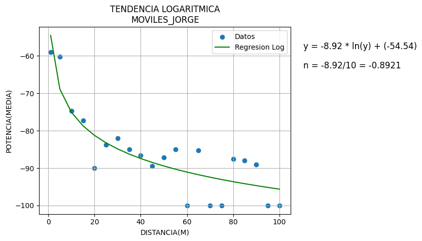

```
-0.8920610230259525
```

```python
tendenciaLog(calculosJorgeMoviles, "MOVILES_JORGE")
```

**OKOMURA HATA**

|  | distancia(m) | LP(dB) | PrxOkomuraHata(dBm) |
| --- | --- | --- | --- |
| 0 | 1.0 | 26.417000 | 15.583000 |
| 1 | 5.0 | 56.002887 | -14.002887 |
| 2 | 10.0 | 68.744835 | -26.744835 |
| 3 | 15.0 | 76.198397 | -34.198397 |
| 4 | 20.0 | 81.486783 | -39.486783 |
| 5 | 25.0 | 85.588774 | -43.588774 |
| 6 | 30.0 | 88.940345 | -46.940345 |
| 7 | 35.0 | 91.774057 | -49.774057 |
| 8 | 40.0 | 94.228731 | -52.228731 |
| 9 | 45.0 | 96.393906 | -54.393906 |
| 10 | 50.0 | 98.330722 | -56.330722 |
| 11 | 55.0 | 100.082785 | -58.082785 |
| 12 | 60.0 | 101.682293 | -59.682293 |
| 13 | 65.0 | 103.153697 | -61.153697 |
| 14 | 70.0 | 104.516005 | -62.516005 |
| 15 | 75.0 | 105.784284 | -63.784284 |
| 16 | 80.0 | 106.970679 | -64.970679 |
| 17 | 85.0 | 108.085126 | -66.085126 |
| 18 | 90.0 | 109.135854 | -67.135854 |
| 19 | 95.0 | 110.129758 | -68.129758 |
| 20 | 100.0 | 111.072670 | -69.072670 |

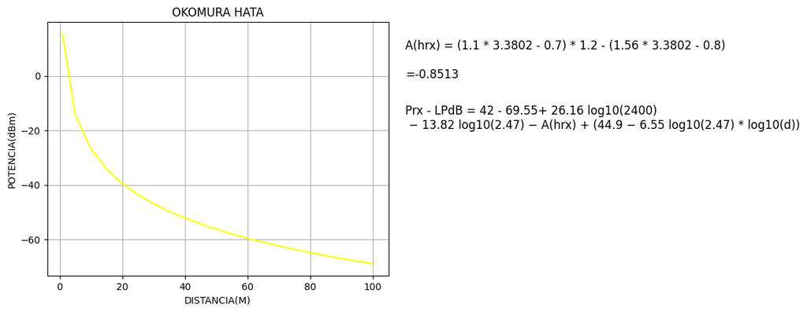

```python
okomuraHataModeljorge = okomuraHataModel(calculosJorgeMoviles, 2400, 2.47, 1.2, PtxMovilesJoge)
okomuraHataModeljorge
```

**COST 231 WALFISH IKEGAMI**

|  | distancia(m) | LP(dB) | PrxCost231_Wal_Ike(dBm) |
| --- | --- | --- | --- |
| 0 | 1.0 | 32.204225 | 9.795775 |
| 1 | 5.0 | 50.377445 | -8.377445 |
| 2 | 10.0 | 58.204225 | -16.204225 |
| 3 | 15.0 | 62.782598 | -20.782598 |
| 4 | 20.0 | 66.031005 | -24.031005 |
| 5 | 25.0 | 68.550665 | -26.550665 |
| 6 | 30.0 | 70.609377 | -28.609377 |
| 7 | 35.0 | 72.349994 | -30.349994 |
| 8 | 40.0 | 73.857785 | -31.857785 |
| 9 | 45.0 | 75.187750 | -33.187750 |
| 10 | 50.0 | 76.377445 | -34.377445 |
| 11 | 55.0 | 77.453655 | -35.453655 |
| 12 | 60.0 | 78.436157 | -36.436157 |
| 13 | 65.0 | 79.339972 | -37.339972 |
| 14 | 70.0 | 80.176774 | -38.176774 |
| 15 | 75.0 | 80.955818 | -38.955818 |
| 16 | 80.0 | 81.684564 | -39.684564 |
| 17 | 85.0 | 82.369117 | -40.369117 |
| 18 | 90.0 | 83.014530 | -41.014530 |
| 19 | 95.0 | 83.625039 | -41.625039 |
| 20 | 100.0 | 84.204225 | -42.204225 |

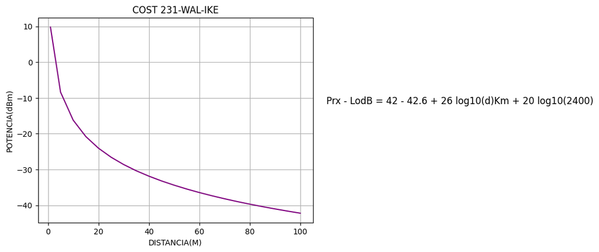

```python
cost231_Wal_Ikejorge = cost231_Wal_Ike(calculosJorgeMoviles, 2400, PtxMovilesJoge)
cost231_Wal_Ikejorge
```

**MODELO ERICSSON**

|  | distancia(m) | LP(dB) | PrxEricsson(dBm) |
| --- | --- | --- | --- |
| 0 | 1 | 27.261382 | 14.738618 |
| 1 | 5 | 59.738232 | -17.738232 |
| 2 | 10 | 73.725250 | -31.725250 |
| 3 | 15 | 81.907131 | -39.907131 |
| 4 | 20 | 87.712268 | -45.712268 |
| 5 | 25 | 92.215082 | -50.215082 |
| 6 | 30 | 95.894149 | -53.894149 |
| 7 | 35 | 99.004756 | -57.004756 |
| 8 | 40 | 101.699286 | -59.699286 |
| 9 | 45 | 104.076030 | -62.076030 |
| 10 | 50 | 106.202100 | -64.202100 |
| 11 | 55 | 108.125365 | -66.125365 |
| 12 | 60 | 109.881167 | -67.881167 |
| 13 | 65 | 111.496349 | -69.496349 |
| 14 | 70 | 112.991774 | -70.991774 |
| 15 | 75 | 114.383981 | -72.383981 |
| 16 | 80 | 115.686304 | -73.686304 |
| 17 | 85 | 116.909649 | -74.909649 |
| 18 | 90 | 118.063048 | -76.063048 |
| 19 | 95 | 119.154071 | -77.154071 |
| 20 | 100 | 120.189118 | -78.189118 |

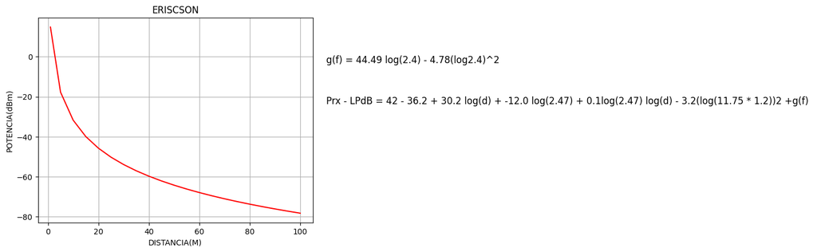

```python
a0 = 36.2
a1 = 30.2
a2 = -12.0
a3 = 0.1
modelo_ericssonjorge = modelo_ericsson(calculosJorgeMoviles, 2.47, 1.2, 2.4, PtxMovilesJoge, a0, a1, a2, a3)
modelo_ericssonjorge
```

**MODELO KEVIN**

Prxk(dBm) = (Media(Mediciones) + (Ptx - OH) + (Ptx - COST231WI) + (Ptx - Ericsson))/4

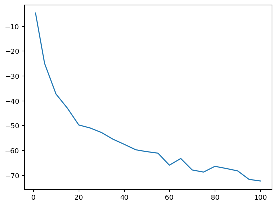

|  | distancia metros | Media | PrxOkomuraHata(dBm) | PrxCost231_Wal_Ike(dBm) | PrxEricsson(dBm) | Modelo Kevin(dBm) |
| --- | --- | --- | --- | --- | --- | --- |
| 0 | 1 | -58.9859 | 15.583000 | 9.795775 | 14.738618 | -4.717127 |
| 1 | 5 | -60.1633 | -14.002887 | -8.377445 | -17.738232 | -25.070466 |
| 2 | 10 | -74.7403 | -26.744835 | -16.204225 | -31.725250 | -37.353652 |
| 3 | 15 | -77.2778 | -34.198397 | -20.782598 | -39.907131 | -43.041481 |
| 4 | 20 | -90.0000 | -39.486783 | -24.031005 | -45.712268 | -49.807514 |
| 5 | 25 | -83.7500 | -43.588774 | -26.550665 | -50.215082 | -51.026130 |
| 6 | 30 | -82.0000 | -46.940345 | -28.609377 | -53.894149 | -52.860968 |
| 7 | 35 | -85.0000 | -49.774057 | -30.349994 | -57.004756 | -55.532202 |
| 8 | 40 | -86.6667 | -52.228731 | -31.857785 | -59.699286 | -57.613125 |
| 9 | 45 | -89.5000 | -54.393906 | -33.187750 | -62.076030 | -59.789422 |
| 10 | 50 | -87.2222 | -56.330722 | -34.377445 | -64.202100 | -60.533117 |
| 11 | 55 | -85.0000 | -58.082785 | -35.453655 | -66.125365 | -61.165451 |
| 12 | 60 | -100.0000 | -59.682293 | -36.436157 | -67.881167 | -65.999904 |
| 13 | 65 | -85.2500 | -61.153697 | -37.339972 | -69.496349 | -63.310005 |
| 14 | 70 | -100.0000 | -62.516005 | -38.176774 | -70.991774 | -67.921138 |
| 15 | 75 | -100.0000 | -63.784284 | -38.955818 | -72.383981 | -68.781021 |
| 16 | 80 | -87.5000 | -64.970679 | -39.684564 | -73.686304 | -66.460387 |
| 17 | 85 | -88.0000 | -66.085126 | -40.369117 | -74.909649 | -67.340973 |
| 18 | 90 | -89.0000 | -67.135854 | -41.014530 | -76.063048 | -68.303358 |
| 19 | 95 | -100.0000 | -68.129758 | -41.625039 | -77.154071 | -71.727217 |
| 20 | 100 | -100.0000 | -69.072670 | -42.204225 | -78.189118 | -72.366503 |

```python
movilesJogeModeloKevin = pd.DataFrame({"distancia metros" : calculosJorgeMoviles["distancia metros"],
                                      "Media": calculosJorgeMoviles["Media"],
                                      "PrxOkomuraHata(dBm)": okomuraHataModeljorge["PrxOkomuraHata(dBm)"],
                                      "PrxCost231_Wal_Ike(dBm)": cost231_Wal_Ikejorge["PrxCost231_Wal_Ike(dBm)"],
                                      "PrxEricsson(dBm)": modelo_ericssonjorge["PrxEricsson(dBm)"],
                                      "Modelo Kevin(dBm)": (calculosJorgeMoviles["Media"]+
                                                       okomuraHataModeljorge["PrxOkomuraHata(dBm)"]+
                                                       cost231_Wal_Ikejorge["PrxCost231_Wal_Ike(dBm)"]+
                                                       modelo_ericssonjorge["PrxEricsson(dBm)"])/4
                                      })
plt.plot(movilesJogeModeloKevin["distancia metros"], movilesJogeModeloKevin["Modelo Kevin(dBm)"])
plt.show()
movilesJogeModeloKevin
```

**MODELOS**

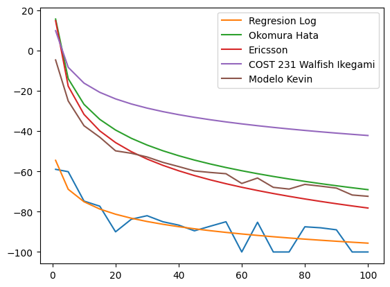

```python
x_movilesJorge = calculosJorgeMoviles["distancia metros"]
coefficients = np.polyfit(np.log(x_movilesJorge), calculosJorgeMoviles["Media"], 1)
trend_line = np.poly1d(coefficients)

plt.plot(x_movilesJorge, calculosJorgeMoviles["Media"])
plt.plot(x_movilesJorge, trend_line(np.log(x_movilesJorge)), label="Regresion Log")
plt.plot(x_movilesJorge, okomuraHataModeljorge["PrxOkomuraHata(dBm)"], label="Okomura Hata")
plt.plot(x_movilesJorge, modelo_ericssonjorge["PrxEricsson(dBm)"], label="Ericsson")
plt.plot(x_movilesJorge, cost231_Wal_Ikejorge["PrxCost231_Wal_Ike(dBm)"], label="COST 231 Walfish Ikegami")
plt.plot(x_movilesJorge, movilesJogeModeloKevin["Modelo Kevin(dBm)"], label="Modelo Kevin")
plt.legend()
plt.show()
```

# **VILLA2024**

```python
calculosvilla2024 = estadisticas(Villa2024)
calculosvilla2024
```

|  | Punto | distancia metros | Media | Error típico | Mediana | Moda | Desviación estándar | Var. muestra | Curtosis | Coef. asimetría | Rango | Mínimo | Máximo | Suma | Cuenta |
| --- | --- | --- | --- | --- | --- | --- | --- | --- | --- | --- | --- | --- | --- | --- | --- |
| 0 | Punto0 | 1 | -38.5714 | 0.7972 | -38.0 | -38 | 5.1662 | 26.6899 | 0.3980 | -0.6107 | 20 | -50 | -30 | -1620 | 42 |
| 1 | Punto1 | 5 | -39.2400 | 0.9955 | -38.0 | -49 | 4.9773 | 24.7733 | 0.1661 | -1.0547 | 16 | -49 | -33 | -981 | 25 |
| 2 | Punto2 | 10 | -46.7831 | 0.2175 | -47.0 | -47 | 1.9819 | 3.9280 | -0.5815 | 0.2112 | 8 | -50 | -42 | -3883 | 83 |
| 3 | Punto3 | 15 | -49.6585 | 0.2077 | -50.0 | -50 | 1.8805 | 3.5363 | 14.0765 | -2.6349 | 13 | -59 | -46 | -4072 | 82 |
| 4 | Punto4 | 20 | -68.6386 | 0.5878 | -69.0 | -69 | 5.3547 | 28.6726 | 5.6085 | 1.7382 | 30 | -77 | -47 | -5697 | 83 |
| 5 | Punto5 | 25 | -60.9211 | 0.4869 | -60.0 | -59 | 4.2450 | 18.0204 | 2.5939 | -1.3247 | 21 | -75 | -54 | -4630 | 76 |
| 6 | Punto6 | 30 | -57.7000 | 0.3595 | -57.0 | -57 | 3.2155 | 10.3392 | -0.2646 | -0.3160 | 14 | -65 | -51 | -4616 | 80 |
| 7 | Punto7 | 35 | -57.2432 | 0.4716 | -57.0 | -59 | 4.0572 | 16.4606 | 6.5458 | -1.8957 | 23 | -74 | -51 | -4236 | 74 |
| 8 | Punto8 | 40 | -56.9718 | 0.4436 | -56.0 | -56 | 3.7377 | 13.9706 | -0.7852 | -0.0700 | 14 | -64 | -50 | -4045 | 71 |
| 9 | Punto9 | 45 | -63.9189 | 0.4466 | -64.0 | -64 | 3.8419 | 14.7605 | 2.2044 | -1.0527 | 20 | -77 | -57 | -4730 | 74 |
| 10 | Punto10 | 50 | -64.6562 | 0.6444 | -64.0 | -62 | 5.1554 | 26.5784 | 3.1747 | -1.4296 | 27 | -82 | -55 | -4138 | 64 |
| 11 | Punto11 | 55 | -63.0000 | 0.5651 | -62.0 | -61 | 4.1138 | 16.9231 | 0.9494 | -0.2894 | 19 | -74 | -55 | -3339 | 53 |
| 12 | Punto12 | 60 | -66.6129 | 0.9058 | -66.0 | -66 | 7.1319 | 50.8641 | -0.9726 | -0.2614 | 24 | -80 | -56 | -4130 | 62 |
| 13 | Punto13 | 65 | -64.4211 | 0.8337 | -64.0 | -61 | 5.1393 | 26.4125 | 0.4997 | -0.8631 | 20 | -77 | -57 | -2448 | 38 |
| 14 | Punto14 | 70 | -59.8824 | 0.7214 | -59.0 | -59 | 5.9489 | 35.3889 | 4.0400 | -1.7794 | 29 | -81 | -52 | -4072 | 68 |
| 15 | Punto15 | 75 | -69.6000 | 1.3962 | -69.5 | -70 | 6.2442 | 38.9895 | -0.1440 | -0.3157 | 22 | -81 | -59 | -1392 | 20 |
| 16 | Punto16 | 80 | -65.4167 | 0.7683 | -66.0 | -66 | 3.7639 | 14.1667 | -0.9111 | -0.0614 | 12 | -72 | -60 | -1570 | 24 |
| 17 | Punto17 | 85 | -62.4615 | 0.5591 | -61.0 | -61 | 4.0315 | 16.2534 | 0.3559 | -0.5898 | 16 | -72 | -56 | -3248 | 52 |
| 18 | Punto18 | 90 | -65.8667 | 0.9441 | -65.0 | -69 | 5.1711 | 26.7402 | 0.3148 | -0.8802 | 19 | -78 | -59 | -1976 | 30 |
| 19 | Punto19 | 95 | -67.0000 | 0.7826 | -67.0 | -66 | 4.0668 | 16.5385 | -0.4484 | 0.6337 | 13 | -72 | -59 | -1809 | 27 |
| 20 | Punto20 | 100 | -71.8571 | 1.0980 | -69.5 | -69 | 5.8100 | 33.7566 | -1.2734 | -0.4496 | 17 | -81 | -64 | -2012 | 28 |

**GRAFICA Y ANEXO DE REGRESEION LOGARITMICA**

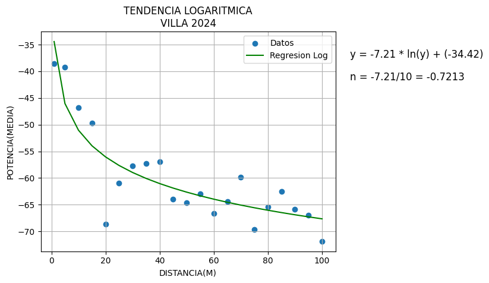

```
-0.7212571595393974
```

```python
tendenciaLog(calculosvilla2024, "VILLA 2024")
```

**OKOMURA HATA**

|  | distancia(m) | LP(dB) | PrxOkomuraHata(dBm) |
| --- | --- | --- | --- |
| 0 | 1.0 | 26.417000 | 5.583000 |
| 1 | 5.0 | 56.002887 | -24.002887 |
| 2 | 10.0 | 68.744835 | -36.744835 |
| 3 | 15.0 | 76.198397 | -44.198397 |
| 4 | 20.0 | 81.486783 | -49.486783 |
| 5 | 25.0 | 85.588774 | -53.588774 |
| 6 | 30.0 | 88.940345 | -56.940345 |
| 7 | 35.0 | 91.774057 | -59.774057 |
| 8 | 40.0 | 94.228731 | -62.228731 |
| 9 | 45.0 | 96.393906 | -64.393906 |
| 10 | 50.0 | 98.330722 | -66.330722 |
| 11 | 55.0 | 100.082785 | -68.082785 |
| 12 | 60.0 | 101.682293 | -69.682293 |
| 13 | 65.0 | 103.153697 | -71.153697 |
| 14 | 70.0 | 104.516005 | -72.516005 |
| 15 | 75.0 | 105.784284 | -73.784284 |
| 16 | 80.0 | 106.970679 | -74.970679 |
| 17 | 85.0 | 108.085126 | -76.085126 |
| 18 | 90.0 | 109.135854 | -77.135854 |
| 19 | 95.0 | 110.129758 | -78.129758 |
| 20 | 100.0 | 111.072670 | -79.072670 |

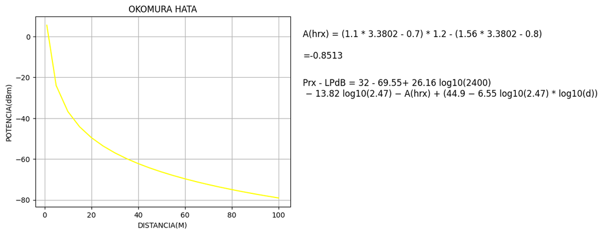

```python
okomuraHataModelvilla=okomuraHataModel(calculosvilla2024, 2400, 2.47, 1.2, ptxVilla2024)
okomuraHataModelvilla
```

**COST 231 WALFISH IKEGAMI**

|  | distancia(m) | LP(dB) | PrxCost231_Wal_Ike(dBm) |
| --- | --- | --- | --- |
| 0 | 1.0 | 32.204225 | -0.204225 |
| 1 | 5.0 | 50.377445 | -18.377445 |
| 2 | 10.0 | 58.204225 | -26.204225 |
| 3 | 15.0 | 62.782598 | -30.782598 |
| 4 | 20.0 | 66.031005 | -34.031005 |
| 5 | 25.0 | 68.550665 | -36.550665 |
| 6 | 30.0 | 70.609377 | -38.609377 |
| 7 | 35.0 | 72.349994 | -40.349994 |
| 8 | 40.0 | 73.857785 | -41.857785 |
| 9 | 45.0 | 75.187750 | -43.187750 |
| 10 | 50.0 | 76.377445 | -44.377445 |
| 11 | 55.0 | 77.453655 | -45.453655 |
| 12 | 60.0 | 78.436157 | -46.436157 |
| 13 | 65.0 | 79.339972 | -47.339972 |
| 14 | 70.0 | 80.176774 | -48.176774 |
| 15 | 75.0 | 80.955818 | -48.955818 |
| 16 | 80.0 | 81.684564 | -49.684564 |
| 17 | 85.0 | 82.369117 | -50.369117 |
| 18 | 90.0 | 83.014530 | -51.014530 |
| 19 | 95.0 | 83.625039 | -51.625039 |
| 20 | 100.0 | 84.204225 | -52.204225 |

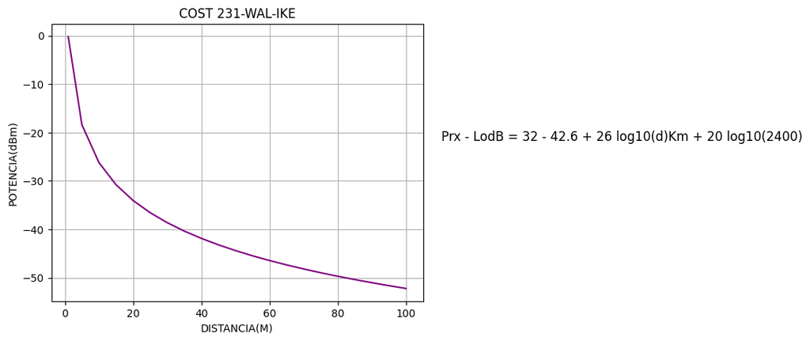

```python
cost231_Wal_Ikevilla = cost231_Wal_Ike(calculosvilla2024, 2400, ptxVilla2024)
cost231_Wal_Ikevilla
```

**MODELO ERICSSON**

|  | distancia(m) | LP(dB) | PrxEricsson(dBm) |
| --- | --- | --- | --- |
| 0 | 1 | 27.261382 | 4.738618 |
| 1 | 5 | 59.738232 | -27.738232 |
| 2 | 10 | 73.725250 | -41.725250 |
| 3 | 15 | 81.907131 | -49.907131 |
| 4 | 20 | 87.712268 | -55.712268 |
| 5 | 25 | 92.215082 | -60.215082 |
| 6 | 30 | 95.894149 | -63.894149 |
| 7 | 35 | 99.004756 | -67.004756 |
| 8 | 40 | 101.699286 | -69.699286 |
| 9 | 45 | 104.076030 | -72.076030 |
| 10 | 50 | 106.202100 | -74.202100 |
| 11 | 55 | 108.125365 | -76.125365 |
| 12 | 60 | 109.881167 | -77.881167 |
| 13 | 65 | 111.496349 | -79.496349 |
| 14 | 70 | 112.991774 | -80.991774 |
| 15 | 75 | 114.383981 | -82.383981 |
| 16 | 80 | 115.686304 | -83.686304 |
| 17 | 85 | 116.909649 | -84.909649 |
| 18 | 90 | 118.063048 | -86.063048 |
| 19 | 95 | 119.154071 | -87.154071 |
| 20 | 100 | 120.189118 | -88.189118 |

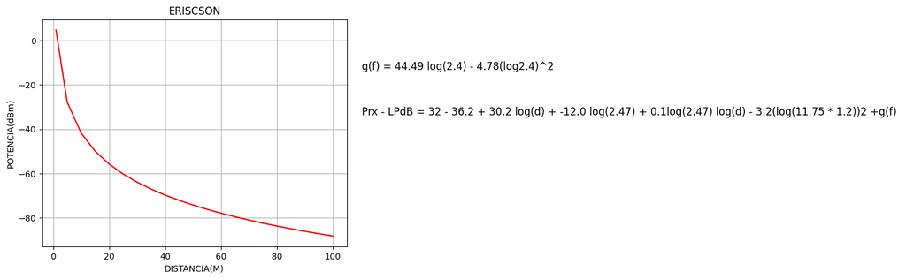

```python
a0 = 36.2
a1 = 30.2
a2 = -12.0
a3 = 0.1
modelo_ericssonvilla = modelo_ericsson(calculosvilla2024, 2.47, 1.2, 2.4, ptxVilla2024, a0, a1, a2, a3)
modelo_ericssonvilla
```

**MODELO KEVIN**

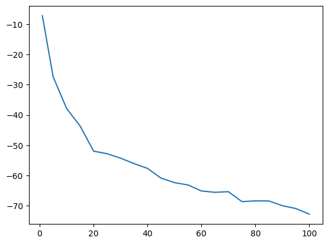

|  | distancia metros | Media | PrxOkomuraHata(dBm) | PrxCost231_Wal_Ike(dBm) | PrxEricsson(dBm) | Modelo Kevin(dBm) |
| --- | --- | --- | --- | --- | --- | --- |
| 0 | 1 | -38.5714 | 5.583000 | -0.204225 | 4.738618 | -7.113502 |
| 1 | 5 | -39.2400 | -24.002887 | -18.377445 | -27.738232 | -27.339641 |
| 2 | 10 | -46.7831 | -36.744835 | -26.204225 | -41.725250 | -37.864352 |
| 3 | 15 | -49.6585 | -44.198397 | -30.782598 | -49.907131 | -43.636656 |
| 4 | 20 | -68.6386 | -49.486783 | -34.031005 | -55.712268 | -51.967164 |
| 5 | 25 | -60.9211 | -53.588774 | -36.550665 | -60.215082 | -52.818905 |
| 6 | 30 | -57.7000 | -56.940345 | -38.609377 | -63.894149 | -54.285968 |
| 7 | 35 | -57.2432 | -59.774057 | -40.349994 | -67.004756 | -56.093002 |
| 8 | 40 | -56.9718 | -62.228731 | -41.857785 | -69.699286 | -57.689400 |
| 9 | 45 | -63.9189 | -64.393906 | -43.187750 | -72.076030 | -60.894147 |
| 10 | 50 | -64.6562 | -66.330722 | -44.377445 | -74.202100 | -62.391617 |
| 11 | 55 | -63.0000 | -68.082785 | -45.453655 | -76.125365 | -63.165451 |
| 12 | 60 | -66.6129 | -69.682293 | -46.436157 | -77.881167 | -65.153129 |
| 13 | 65 | -64.4211 | -71.153697 | -47.339972 | -79.496349 | -65.602780 |
| 14 | 70 | -59.8824 | -72.516005 | -48.176774 | -80.991774 | -65.391738 |
| 15 | 75 | -69.6000 | -73.784284 | -48.955818 | -82.383981 | -68.681021 |
| 16 | 80 | -65.4167 | -74.970679 | -49.684564 | -83.686304 | -68.439562 |
| 17 | 85 | -62.4615 | -76.085126 | -50.369117 | -84.909649 | -68.456348 |
| 18 | 90 | -65.8667 | -77.135854 | -51.014530 | -86.063048 | -70.020033 |
| 19 | 95 | -67.0000 | -78.129758 | -51.625039 | -87.154071 | -70.977217 |
| 20 | 100 | -71.8571 | -79.072670 | -52.204225 | -88.189118 | -72.830778 |

```python
VillaModeloKevin = pd.DataFrame({
    "distancia metros": calculosvilla2024["distancia metros"],
    "Media": calculosvilla2024["Media"],
    "PrxOkomuraHata(dBm)": okomuraHataModelvilla["PrxOkomuraHata(dBm)"],
    "PrxCost231_Wal_Ike(dBm)": cost231_Wal_Ikevilla["PrxCost231_Wal_Ike(dBm)"],
    "PrxEricsson(dBm)": modelo_ericssonvilla["PrxEricsson(dBm)"],
    "Modelo Kevin(dBm)": (calculosvilla2024["Media"] +
                          okomuraHataModelvilla["PrxOkomuraHata(dBm)"] +
                          cost231_Wal_Ikevilla["PrxCost231_Wal_Ike(dBm)"] +
                          modelo_ericssonvilla["PrxEricsson(dBm)"]) / 4
})

plt.plot(VillaModeloKevin["distancia metros"], VillaModeloKevin["Modelo Kevin(dBm)"])
plt.show()
VillaModeloKevin
```

**MODELOS**

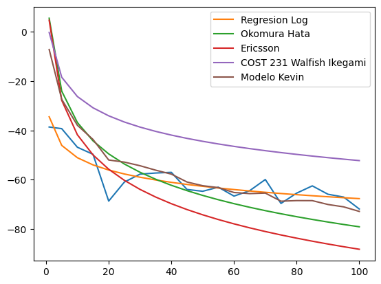

```python
x_villa2024 = calculosvilla2024["distancia metros"]
coefficients = np.polyfit(np.log(x_movilesJorge), calculosvilla2024["Media"], 1)
trend_line = np.poly1d(coefficients)

plt.plot(x_villa2024, calculosvilla2024["Media"])
plt.plot(x_villa2024, trend_line(np.log(x_villa2024)), label="Regresion Log")
plt.plot(x_villa2024, okomuraHataModelvilla["PrxOkomuraHata(dBm)"], label="Okomura Hata")
plt.plot(x_villa2024, modelo_ericssonvilla["PrxEricsson(dBm)"], label="Ericsson")
plt.plot(x_villa2024, cost231_Wal_Ikevilla["PrxCost231_Wal_Ike(dBm)"], label="COST 231 Walfish Ikegami")
plt.plot(x_villa2024, VillaModeloKevin["Modelo Kevin(dBm)"], label="Modelo Kevin")

plt.legend()
plt.show()
```

**INCORPORAR TABLAS DE ESTADISTICA PARA EL EXCEL**

```python
JorgeMoviles["TABLA_ESTADISTICA"] = calculosJorgeMoviles
Villa2024["TABLA_ESTADISTICA"] = calculosvilla2024
```

**EXPORTAR EXCEL**

```python
with pd.ExcelWriter('archivos/MOVILES_JORGE.xlsx') as writer:
    for key, df in JorgeMoviles.items():
        df.to_excel(writer, sheet_name=key, index=False)

print("Hojas creadas correctamente.")
```

```
Hojas creadas correctamente.
```

```python
with pd.ExcelWriter('archivos/villa2024.xlsx') as writer:
    for key, df in Villa2024.items():
        df.to_excel(writer, sheet_name=key, index=False)

print("Hojas creadas correctamente.")
```

```
Hojas creadas correctamente.
```